# TABA Assignment 1 Name: Vivek Agarwal ISB ID: 71710035

### Importing all Important Library to analyze tweets

```r
#____________________________________________# Loading all libraries______________________________
library(stringr);library(tm);library(dplyr);library(tidytext);library(tidyr);require(tibble)
library(text2vec);library(ggplot2);library(wordcloud);library(RColorBrewer);library(qdap)
```

#### Importing and reading IBMResearch_tweets file

```r
#____________________________________________#Reading tweets______________________________________
#tweet1 <- read.csv(file.choose())
tweet1 <- read.csv("/Users/monicaagarwal/Desktop/ISB/Term 1-residency 2/Term 2/TABA/Assignment/Assignment-1/IBMResearch_tweets.csv", header = TRUE)
```

#### Using Regex and pattern matching. The tweets are cleaned and text corpus is created.

```r
#____________________________________________#Cleaning tweets______________________________________
clean_text = function(tweet) {
tweet <-tolower(tweet$text)
tweet = stringr::str_replace_all(tweet, "[^a-zA-Z#@0-9\\s]", "") #remove unwanted word
tweet = stringr::str_replace_all(tweet, "http.*", "") #remove httpslink
tweet = stringr::str_replace_all(tweet, "brt ", "") # remove retweets
tweet = stringr::str_replace_all(tweet, "^[b]", "") #
tweet = stringr::str_replace_all(tweet, "amp", "") #
tweet = gsub("^ ", "", tweet)  # remove blank spaces at the beginning
tweet = gsub(" $", "", tweet) # remove blank spaces at the end
tweet = gsub("\\\\x.*? |\\\\x.*?\'$|\\\\x.*?\"$","", tweet) #  some peculiar pattern
return (tweet)
} # Clean text function ends
text_corpus = clean_text(tweet1)
```

### Extracting Various details from the clean corpus created above and the same is converted into a data frame with folloiwng three columns

1. Text message
2. Twitter Handler (use detail)
3. Hashtag

```r
#______________________________#Extracting and Savings hashtag and user details in a dataframe____
detail = function(corpus) {
df <- NULL
df$user_detail= stringr::str_extract_all(corpus,"@\\w+") # extracting user detail
df$hashtag = stringr::str_extract_all(corpus,"#\\w+") #Extracting hashtag
df$text= stringr::str_replace_all(corpus,"#\\w+", "") #removing hashtag
df$text = stringr::str_replace_all(df$text,"@\\w+", "") # removing user detail
df$text = gsub("[[:punct:]]","",df$text) #remove any unwanted punctuation from the text
df$text= gsub("^ ", "", df$text)  # remove blank spaces at the beginning
df$text= gsub("\\s+$", "", df$text) # remove blank spaces at the end
clean_tweet <-as.data.frame(do.call("cbind", df))
return (clean_tweet)
} # Extracting various detail from text
clean_df = detail(text_corpus)
```

#### Created a word analyzer function which takes input clean text corpus and analyze them based on either monogram or bigram and tokenize it. The fnction returns return a list of

1. Dtm
2. Dataframe,
3. Top words,
4. Wordcloud

```r
word_analyzer = function(txt,ngrams){
  text_df <- data_frame(line = 1:length(txt), text2 = unlist(txt))
  #__________________________________#Analyzing text using tidytext format (uni-bi-grams)___________________
  word_token_grams = text_df %>% unnest_tokens(word,text2,token = "ngrams", n = ngrams) %>% anti_join(stop_words) %>%
    count(word, sort = TRUE) %>% mutate(id = 1)
  if (ngrams == 1)
  {
    word_grams <- cast_dtm(word_token_grams,document = id,term = word,value = n)
    data_gram <- data.frame(word_token_grams)
    top_words <- word_token_grams %>% filter(n > 50) %>% mutate(word = reorder(word, n)) %>% ggplot(aes(word, n)) +geom_col() +
      xlab(NULL) +coord_flip()
    set.seed(1234)
    wc<- wordcloud(words = data_gram$word, freq = data_gram$n, min.freq = 1,
              max.words=200, random.order=FALSE, rot.per=0.35,
              colors=brewer.pal(8, "Dark2"))
    mylist <- list("dtm" = word_grams, "df" = data_gram, "top_words" = top_words, "wordcloud" = wc)
  }

  else {
    #____________________________# separate bigrams
    bigrams_separated <- word_token_grams %>%
      separate(word, c("word1", "word2"), sep = " ")
    #____________________________# filtered bigrams
    bigrams_filtered <- bigrams_separated %>%
      filter(!word1 %in% stop_words$word) %>%
      filter(!word2 %in% stop_words$word)
    #____________________________# bigrams united
    bigrams_united <- bigrams_filtered %>%
      unite(word, word1, word2, sep = " ")
    #____________________________#Create DTM of Bigrams
    word_grams <- cast_dtm(bigrams_united,document = id,term = word,value = n)
    #________________________________#Creating plot for most occuring word for bigrams
    data_gram <- data.frame(bigrams_united)
    top_words <- bigrams_united %>% filter(n > 20) %>% mutate(word = reorder(word, n)) %>% ggplot(aes(word, n)) +geom_col() +
      xlab(NULL) +coord_flip()
    set.seed(1234)
    wc<- wordcloud(words = data_gram$word, freq = data_gram$n, min.freq = 1,
                   max.words=200, random.order=FALSE, rot.per=0.35,
                   colors=brewer.pal(8, "Dark2"))
    mylist <- list("dtm" = word_grams, "df" = data_gram, "top_words" = top_words, "wordcloud" = wc)
  }
  return(mylist)
}
```

#### Analyzing Bigrams…

```r
#The function will work only for monogram and bigrams...
analysis <- word_analyzer(clean_df$text, 2)
```

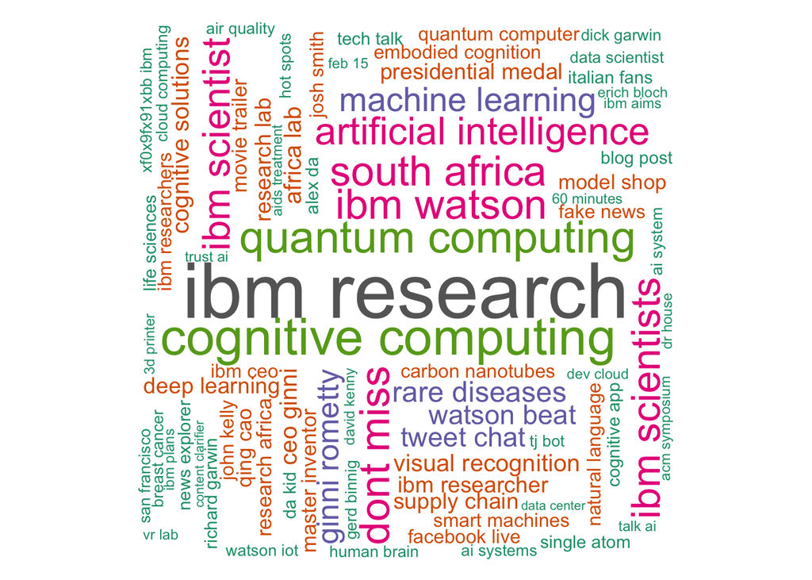

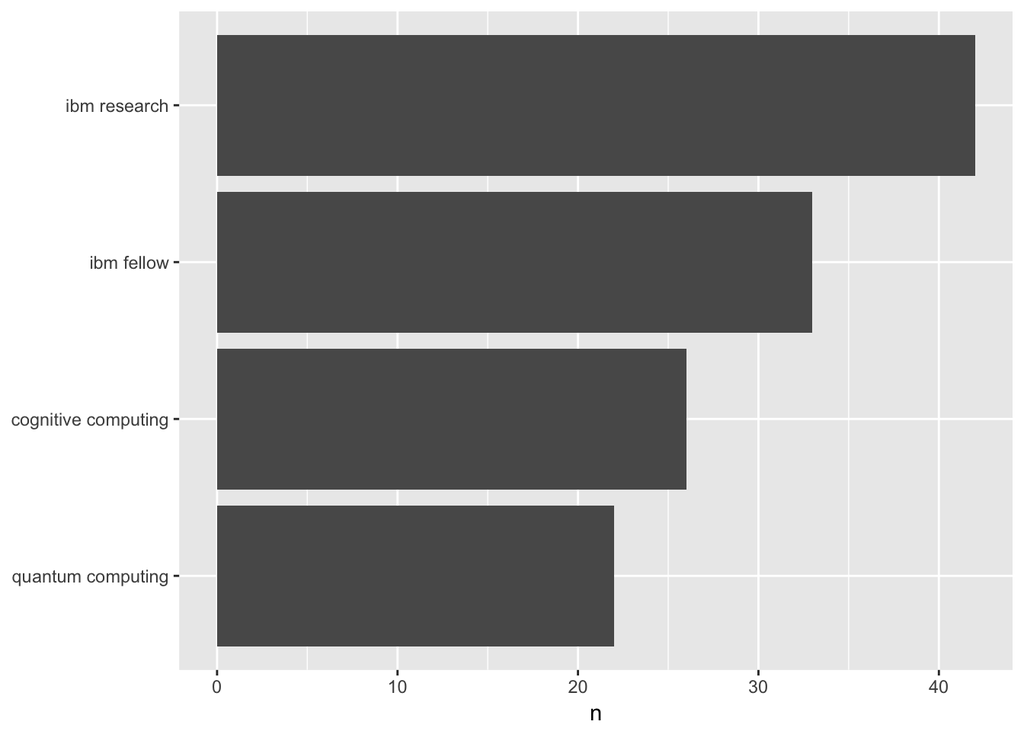

```r
#_______________Top words for Bigram_____________________
analysis$top_words
```

The word cloud and top words reveals that main theme of IBM Research tweeets is around IBM Research and cognitive and quantum computing. computing

#### Now the same function is used to run for Monogram

```r
#The function will work only for monogram and bigrams...
analysis <- word_analyzer(clean_df$text, 1)
```

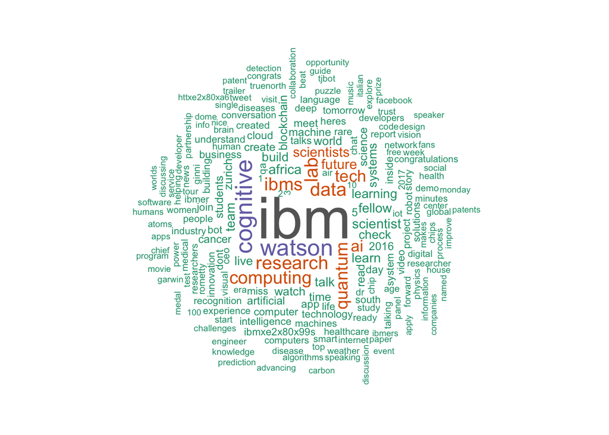

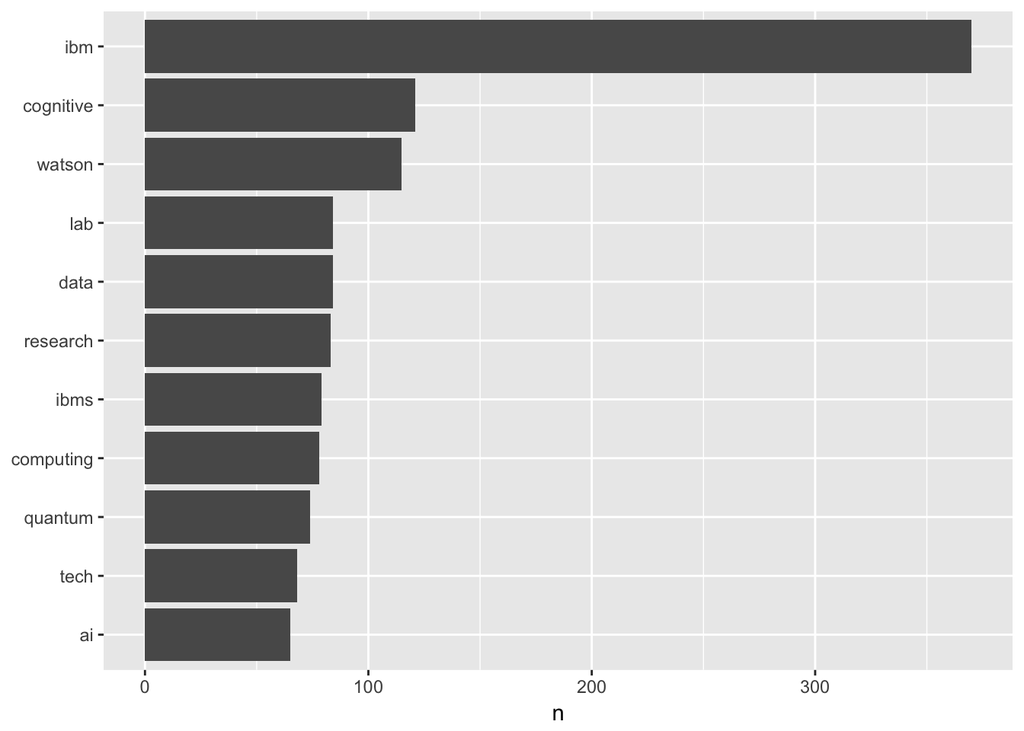

```r
#_______________________Top words for Monogram___________________
analysis$top_words
```

Similar resarch is also visible with monogram as well. Monogram also has prominnet word of watson.

#### Now extracting and top words, handler, hashtag and converting into a data frame

```r
#_________________________________#Top 5 unigrams, hashtag and user profile______________________________
top_profile <- function(cleantext) {
text_df <- data_frame(text2 = unlist(cleantext$text))
top_5_words = text_df %>% unnest_tokens(word, text2) %>% anti_join(stop_words) %>% count(word, sort = TRUE) %>%
 rename(count = n) %>% head(5L)


text_user <- data_frame(user = unlist(cleantext$user_detail))
top_5_user = text_user %>% unnest_tokens(word, user) %>% anti_join(stop_words) %>% count(word, sort = TRUE) %>%
  rename(count = n) %>% head(5L)

text_hashtag <- data_frame(hashtag = unlist(cleantext$hashtag))
top_5_hashtag = text_hashtag %>% unnest_tokens(word, hashtag) %>% anti_join(stop_words) %>% count(word, sort = TRUE) %>%
  rename(count = n)  %>% head(n=5L)

top_dataframe <- data.frame(top_5_words,top_5_hashtag,top_5_user)
colnames(top_dataframe) <- c("Top Words", "Count of  top words", "Top Hashtag", "Count of Hashtag", "Top handler","Count of handler")
return(top_dataframe)
}
top_df = top_profile(clean_df)
top_df
```

```
##   Top Words Count of  top words Top Hashtag Count of Hashtag Top handler
## 1       ibm                 370          ai               98         ibm
## 2 cognitive                 121   ibmwatson               91 ibmresearch
## 3    watson                 115       tjbot               87   ibmwatson
## 4      data                  84 ibmresearch               73  alecurioni
## 5       lab                  84  blockchain               56     banavar
##   Count of handler
## 1              190
## 2              189
## 3              131
## 4               45
## 5               33
```

#### In this section, i am Building DTM and TF-IDF from text2vec to do some more operating to find some patern in the IBM Research corpus.

```r
#__________________________________________#Creating DTM and TFIDF using text2vec__________________
t <- as.character(clean_df$text)
stop = as.character(stop_words$word)
it = itoken(t, progressbar = FALSE)
v = create_vocabulary(it,stopwords= stop) %>% prune_vocabulary(doc_proportion_max = 0.2, term_count_min = 5)    # can change this parm for overly large corpora
vectorizer = vocab_vectorizer(v)
dtm = create_dtm(it, vectorizer)
dim(dtm)
```

```
## [1] 2000  599
```

```r
text_dtm <- as.matrix(dtm)
tfidf = TfIdf$new() # define tfidf model
dtm_tfidf = fit_transform(dtm, tfidf)  # use fit_transform() func

dim(dtm_tfidf)
```

```
## [1] 2000  599
```

#### Performing Latent semantic analysis of the created DTM.

I tried to create clustering in the IBM Research tweets data. In order to find the optimal number of clusters, i have employed elbow curve to find optimal number of clusters..

Bylooking at the elbow curve, we can say that optimal number of clusters seems around 10, but error is very high of about (~212)

By looking at within sum of squares(WSS) error, i have assumed cluster to be at 51 though cluster 60 has minimum WSS error but the error is increasing beyond 51.

The result looks interesting.

```r
#__________________________________________#Building LSA Model using text2vec______________________
# Under regular tf weighting
tdm = t(text_dtm)   # TDM has terms in its rows
print (dim(tdm))
```

```
## [1]  599 2000
```

```r
# define LSA parms
lsa.term = LSA$new(n_topics = 10)     # no. of SVD factors, basically.

tdm_lsa = tdm %>% fit_transform(lsa.term)   # fit_transform() applies LSA parms to TDM object
head(tdm_lsa)    # first few rows of lsa object, view.
```

```
##                  [,1]        [,2]        [,3]        [,4]         [,5]
## vote      0.016282797  0.15127256  0.03927146 -0.04459050  0.022733238
## btwn      0.141381262 -0.04275985  0.02278969  0.02065571 -0.009529441
## financial 0.172981712  0.08896266 -0.18432762  0.07175964 -0.187080142
## cao       0.007769653  0.02378031 -0.01701516  0.03582611 -0.002989872
## train     0.015752560  0.05609206 -0.17162553  0.02989826  0.007145155
## germany   0.179703091  0.12341524 -0.37034778  0.05609679 -0.144225076
##                   [,6]        [,7]         [,8]         [,9]        [,10]
## vote       0.057182255 -0.02591753 -0.130073751  0.069076011 -0.051500109
## btwn       0.022526674  0.01095492 -0.051388441 -0.081671592 -0.003697108
## financial -0.154553153  0.10905725  0.030146337  0.002334904  0.072059064
## cao       -0.004626205 -0.09669421  0.043172879 -0.027131938 -0.118312240
## train     -0.016044072  0.05090875 -0.002300086  0.003891864 -0.003216646
## germany   -0.078072308  0.08361757  0.058051671 -0.015680850  0.218584675
```

```r
#_______________________#creating cluster_______
#______________# clustering and seeing (hopefully) synonym sets
#__________#Elbow Method for finding the optimal number of clusters
set.seed(123)
# Compute and plot wss for k = 2 to k = 100.
k.max <- 60
wss <- sapply(1:k.max,
              function(k){kmeans(tdm_lsa, k, nstart=50,iter.max = 15 )$tot.withinss})
print (wss)
```

```
##  [1] 1301.41852  914.16948  788.60493  678.58961  582.35392  490.49855
##  [7]  406.29849  333.56277  270.20083  212.44403  155.53847  134.21179
## [13]  119.89044  111.17674  104.65059   97.05062   91.34098   87.45362
## [19]   81.94476   78.41233   75.39104   73.00317   70.57232   68.20093
## [25]   66.04523   63.58969   61.69534   59.80384   58.14738   50.64278
## [31]   55.59078   54.30029   52.59634   51.34604   49.42439   48.44530
## [37]   48.20326   46.00655   46.03923   44.66818   43.74521   43.72681
## [43]   42.55412   42.04426   41.21997   40.47858   39.85277   39.63788
## [49]   38.83956   38.68077   27.74630   37.48794   37.55206   36.64639
## [55]   26.49488   36.29913   35.53632   35.16452   34.24398   24.84056
```

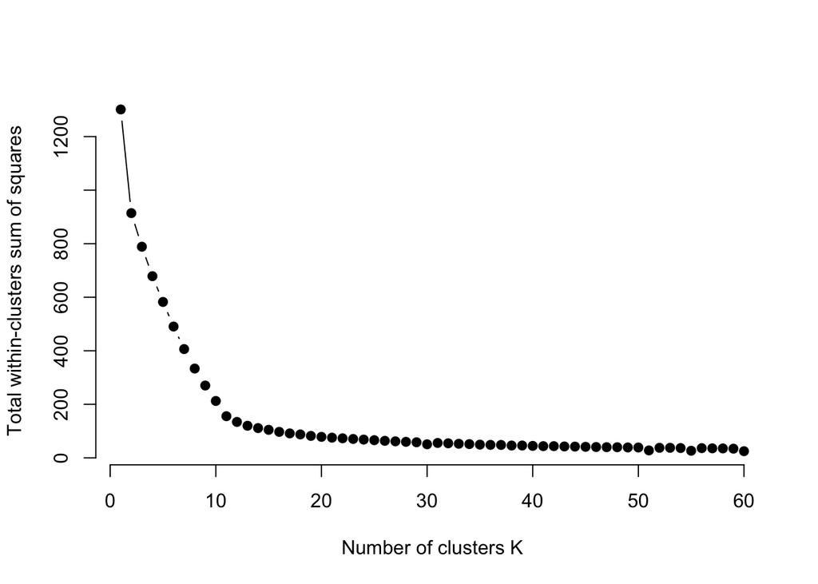

```r
plot(1:k.max, wss,
     type="b", pch = 19, frame = FALSE,
     xlab="Number of clusters K",
     ylab="Total within-clusters sum of squares")
```

```r
tdm_kmeans = kmeans(tdm_lsa, 51,     # no. of clusters to be created. I'm assuming this, not using fit criteria.
                    iter.max = 100)
tdm_kmeans$size
```

```
##  [1] 11  3 35  4  4 18  1  1  4  1 16  3 37  1  1 13  2 12  2  5 19  8 88
## [24] 42  2  9 23  1  1 11  1  1  1 43  2 24  4  1  1 14  2  2 52  6  1 11
## [47]  1  1  9  6 38
```

```r
token.names = rownames(tdm_lsa)
#________________________________________# printing some token clusters
for (i1 in 1:20){print(token.names[(tdm_kmeans$cluster == i1)])}
```

```
##  [1] "age"      "response" "white"    "panel"    "read"     "minutes"
##  [7] "trust"    "smart"    "machines" "house"    "paper"
## [1] "day"      "computer" "cloud"
##  [1] "btwn"          "speaker"       "snapchat"      "finance"
##  [5] "breast"        "partners"      "andreas"       "neurons"
##  [9] "switzerland"   "wexe2x80x99re" "computational" "atoms"
## [13] "molecule"      "resistance"    "collaborate"   "researcher"
## [17] "including"     "plans"         "discussing"    "commercial"
## [21] "dubai"         "link"          "researchers"   "human"
## [25] "skills"        "predictions"   "smith"         "million"
## [29] "1st"           "study"         "technical"     "strategic"
## [33] "whats"         "improve"       "launches"
## [1] "solutions" "era"       "business"  "learn"
## [1] "conversation" "beat"         "build"        "bot"
##  [1] "neuromorphic"  "pioneer"       "api"           "30"
```

[output cut: 37 more lines]

### Since we have functionize the IBM Research tweets, we are utilizing the same fucntion to analyze IBM watson tweets.

The result for IBM watson tweets are somewhat similar to IBM Research tweets.

```r
#______________________Analyzing Watosn tweets Corpus_______________________________

#_____________Reading watson file____________
tw_watson <- read.csv("/Users/monicaagarwal/Desktop/ISB/Term 1-residency 2/Term 2/TABA/Assignment/Assignment-1/IBMwatson_tweets.csv", header = TRUE)

watson_corpus <- clean_text(tw_watson)
watson_clean <- detail(watson_corpus)

#________________Analyzing watson tweets with bi grams____________________
watson_analyzer <- word_analyzer(watson_clean$text,2)
```

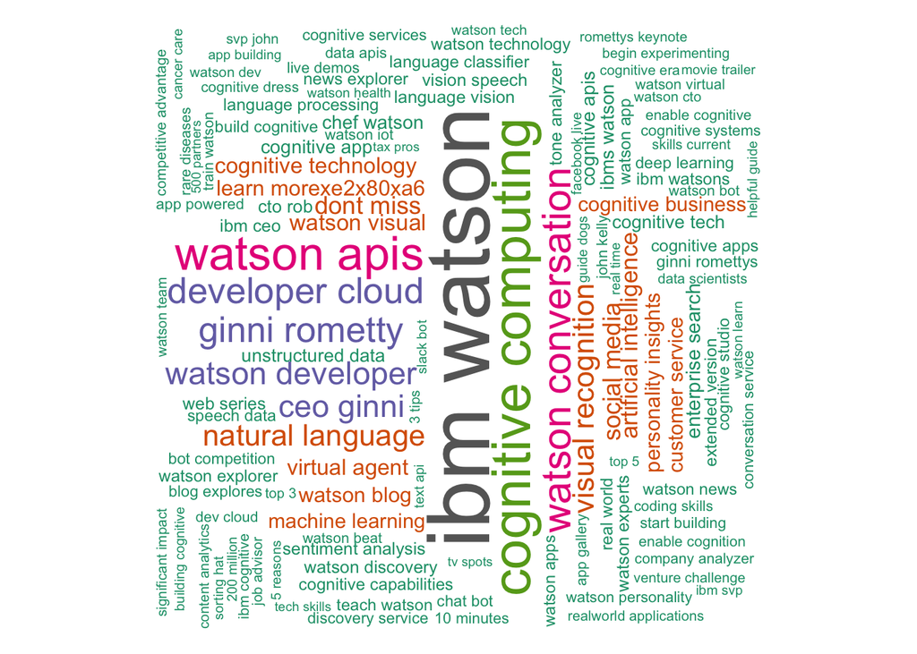

#### Top bigram words in IBM Watson tweets

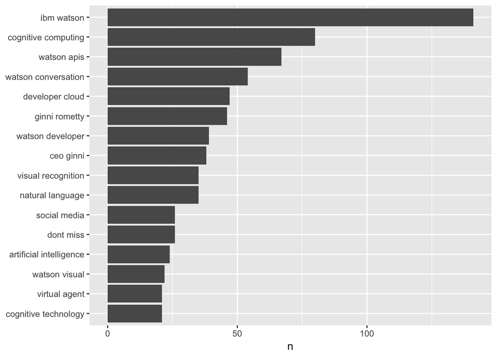

```r
watson_analyzer$top_words
```

### Analyzing Monogram now.

```r
watson_analyzer <- word_analyzer(watson_clean$text,1)
```

[figure not shown]

#### Top monogram words in IBM Watson tweets

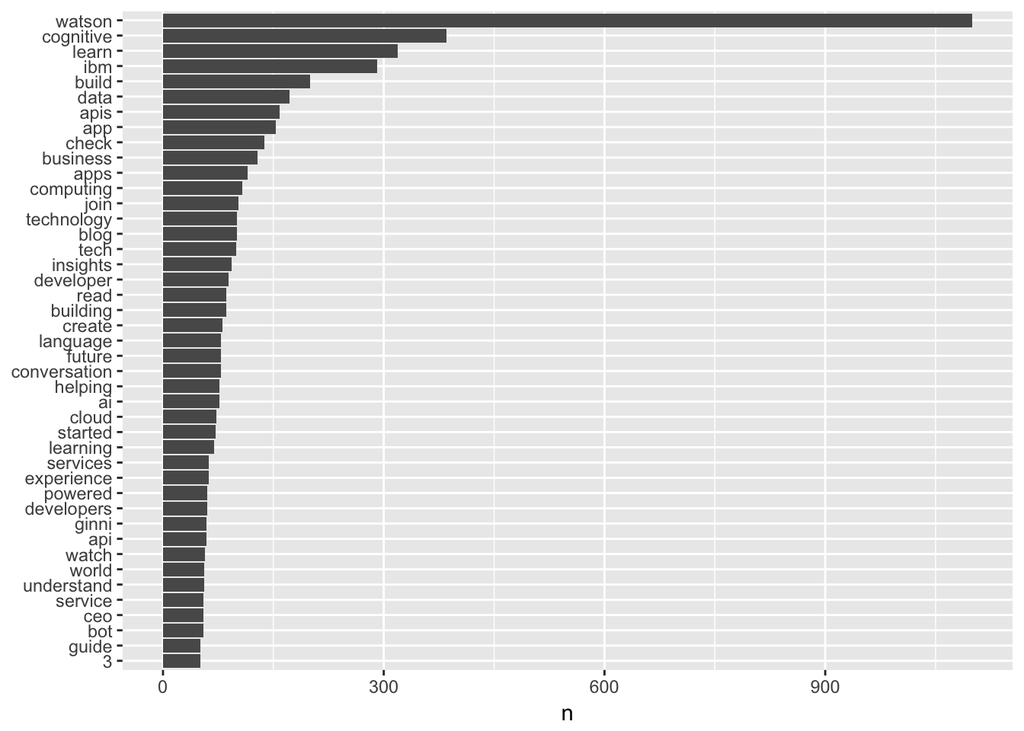

```r
watson_analyzer$top_words
```

#### Top profile details for IBM Watson tweets

```r
top_watson_profile <- top_profile(watson_clean)
top_watson_profile
```

```
##   Top Words Count of  top words  Top Hashtag Count of Hashtag Top handler
## 1    watson                1100    ibmwatson              274   ibmwatson
## 2 cognitive                 385    cognitive              222         ibm
## 3     learn                 319           ai              179  ibmbluemix
## 4       ibm                 291 watsondevcon               96 davidwkenny
## 5     build                 200       ibmwow               73      coastw
##   Count of handler
## 1              298
## 2              266
## 3               68
## 4               57
## 5               53
```